# Practical Machine Learning - Course Project

Ying Yang

13 January 2019

## Overview and Workflow

The purpose of this project is to predict how well the users did their dumbell exercise based on the data collected from accelerometers.

I organised my project in the following workflow:

I first split the training data into validation and training datasets. The validation data set serves as test data for me, as we don’t know the actual outcome, i.e. the ‘classe’ variable, of the test data provided to us.

Then I used some exploratory analysis techniques to understand the data and also check the quality the data. Based on these exploratory analysis, I pre-processed the training data to make sure it is set for modelling. I also pre-processed the validation and test data in the same way.

For prediction modelling, since the outcome variable “classe” is categorical, I selected a few classification models, including Decision Tree with K-fold Cross Validation, Random Forest, and Gradient Boosting. Based on reported accuracies for each model, I finally selected Random Forest as my prediction model, which has a accuracy of 0.9998, 0.0002 out-of-sample-error rate.

```r
# Load the libraries
library(caret)
library(Amelia)
library(dplyr)
```

```r
library(corrplot)
```

## 1. Read the training and testing datasets

```r
training <- read.csv("C:/Users/Yangying/Documents/Practical Machine Learning/pml-training.csv",na.strings=c(""," ", "NA"))

testing <- read.csv("C:/Users/Yangying/Documents/Practical Machine Learning/pml-testing.csv",na.strings=c(""," ", "NA"))
```

## 2. split out a small subset of training data for validation purpose

```r
## set the seed to ensure reproducibility

set.seed(12125)

inValidation<- createDataPartition(y=training$classe,
                                   p=0.25, list=FALSE)

valid<- training[inValidation, ]

training<- training[-inValidation,]
```

## 3.Exploratory analysis and Pre prossing

### 3.1 check the sieze of the training, test and valid data

```r
dim(training)
```

```
## [1] 14715   160
```

```r
dim(testing)
```

```
## [1]  20 160
```

```r
dim(valid)
```

```
## [1] 4907  160
```

### 3.2 Map out the missing values (or the NA values)

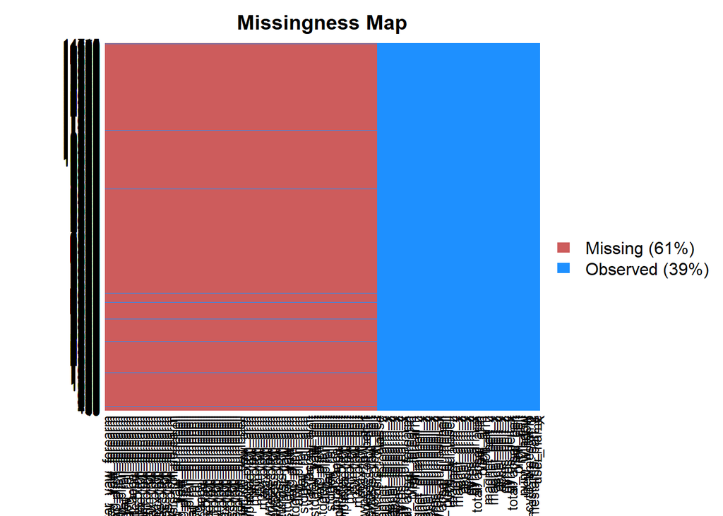

### 3.3 Remove variables with nearly all NA values

```r
navariables<- colnames(training[colSums(is.na(training)) > 0])

training<- select(training, -navariables)

# the first column is just row number, hence should be removed too

training<- training[, -1]
```

### 3.4 check if there are any variables with nearly no variance

```r
nearZeroVar(training, saveMetrics = TRUE)
```

```
##                      freqRatio percentUnique zeroVar   nzv
## user_name             1.105834    0.04077472   FALSE FALSE
## raw_timestamp_part_1  1.066667    5.68807339   FALSE FALSE
## raw_timestamp_part_2  1.000000   88.66462793   FALSE FALSE
## cvtd_timestamp        1.006267    0.13591573   FALSE FALSE
## new_window           48.379195    0.01359157   FALSE  TRUE
## num_window            1.066667    5.83078491   FALSE FALSE
## roll_belt             1.104948    7.73360516   FALSE FALSE
## pitch_belt            1.129496   11.70234455   FALSE FALSE
## yaw_belt              1.122016   12.36153585   FALSE FALSE
## total_accel_belt      1.029544    0.19707781   FALSE FALSE
## gyros_belt_x          1.039024    0.90383962   FALSE FALSE
## gyros_belt_y          1.116576    0.44852192   FALSE FALSE
## gyros_belt_z          1.055011    1.11450900   FALSE FALSE
## accel_belt_x          1.041096    1.10091743   FALSE FALSE
## accel_belt_y          1.123556    0.94461434   FALSE FALSE
## accel_belt_z          1.067466    2.01155284   FALSE FALSE
## magnet_belt_x         1.107011    2.10669385   FALSE FALSE
## magnet_belt_y         1.150538    1.96398233   FALSE FALSE
## magnet_belt_z         1.026163    3.00373768   FALSE FALSE
## roll_arm             48.615385   16.62928984   FALSE FALSE
## pitch_arm            72.257143   19.38158342   FALSE FALSE
## yaw_arm              32.000000   18.21950391   FALSE FALSE
## total_accel_arm       1.060831    0.44852192   FALSE FALSE
## gyros_arm_x           1.018135    4.28814135   FALSE FALSE
## gyros_arm_y           1.502632    2.52123683   FALSE FALSE
## gyros_arm_z           1.156658    1.63778457   FALSE FALSE
## accel_arm_x           1.040000    5.18518519   FALSE FALSE
## accel_arm_y           1.220000    3.58137954   FALSE FALSE
## accel_arm_z           1.020000    5.24634726   FALSE FALSE
## magnet_arm_x          1.014493    8.97723411   FALSE FALSE
## magnet_arm_y          1.084507    5.84437649   FALSE FALSE
## magnet_arm_z          1.034091    8.51512063   FALSE FALSE
## roll_dumbbell         1.028846   86.04145430   FALSE FALSE
## pitch_dumbbell        2.115385   83.84641522   FALSE FALSE
## yaw_dumbbell          1.155556   85.64050289   FALSE FALSE
## total_accel_dumbbell  1.041667    0.29221882   FALSE FALSE
## gyros_dumbbell_x      1.008850    1.61060143   FALSE FALSE
## gyros_dumbbell_y      1.383133    1.84165817   FALSE FALSE
## gyros_dumbbell_z      1.026030    1.31838260   FALSE FALSE
## accel_dumbbell_x      1.023529    2.82704723   FALSE FALSE
## accel_dumbbell_y      1.048649    3.09887870   FALSE FALSE
## accel_dumbbell_z      1.173410    2.74549779   FALSE FALSE
## magnet_dumbbell_x     1.154472    7.33265375   FALSE FALSE
## magnet_dumbbell_y     1.171429    5.61331974   FALSE FALSE
## magnet_dumbbell_z     1.034247    4.52599388   FALSE FALSE
## roll_forearm         11.600000   13.13625552   FALSE FALSE
## pitch_forearm        60.367347   18.17193340   FALSE FALSE
## yaw_forearm          16.427778   12.26639484   FALSE FALSE
## total_accel_forearm   1.165740    0.45531770   FALSE FALSE
## gyros_forearm_x       1.105820    1.93679918   FALSE FALSE
## gyros_forearm_y       1.013514    4.92014951   FALSE FALSE
## gyros_forearm_z       1.170520    2.01155284   FALSE FALSE
## accel_forearm_x       1.234375    5.34148828   FALSE FALSE
## accel_forearm_y       1.050633    6.65307509   FALSE FALSE
## accel_forearm_z       1.000000    3.81923208   FALSE FALSE
## magnet_forearm_x      1.101695    9.99660211   FALSE FALSE
## magnet_forearm_y      1.213115   12.44308529   FALSE FALSE
## magnet_forearm_z      1.069767   11.02956167   FALSE FALSE
## classe                1.469968    0.03397893   FALSE FALSE
```

```r
## new_window is a near zero variable, probably should be removed

nsv<- nearZeroVar(training)

training<- training[, -nsv]
```

### 3.5 check if there are any correlated predictors

In this step I have excluded the outcome variable “classe”, and first 5 predictors, “user_name”, “raw_timestamp_part_1”,“raw_timestamp_part_2”, “cvtd_timestamp” and “num_window”,because they are categorical variables and can’t be used for ‘cor’ function.

```r
M<- cor(training[, -c(1:5, 58)])

diag(M)<- 0

which(abs(M)>0.9, arr.ind=T)
```

```
##                  row col
## total_accel_belt   4   1
## accel_belt_y       9   1
## accel_belt_z      10   1
## accel_belt_x       8   2
## roll_belt          1   4
## accel_belt_y       9   4
## accel_belt_z      10   4
## pitch_belt         2   8
## roll_belt          1   9
## total_accel_belt   4   9
## accel_belt_z      10   9
## roll_belt          1  10
## total_accel_belt   4  10
## accel_belt_y       9  10
## gyros_arm_y       19  18
## gyros_arm_x       18  19
## gyros_dumbbell_z  33  31
## gyros_forearm_z   46  31
## gyros_dumbbell_x  31  33
## gyros_forearm_z   46  33
## gyros_dumbbell_x  31  46
## gyros_dumbbell_z  33  46
```

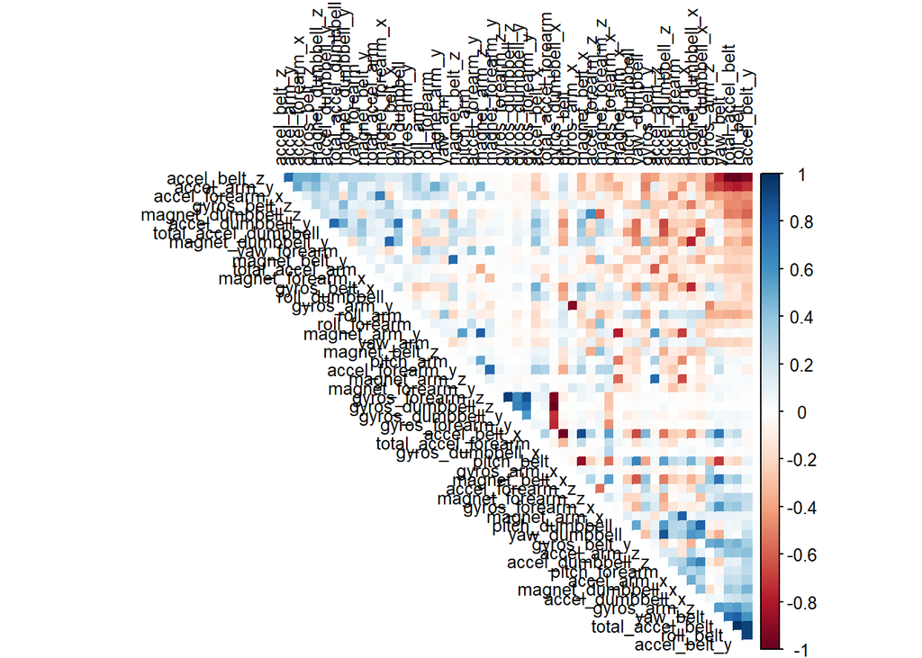

### 3.6 Pre process the testing and validation data in the same way as training data

```r
testing<- select(testing, -navariables)
testing<- testing[,-1]
testing<- testing[, - nsv]

valid<- select(valid, -navariables)
valid<- valid[,-1]
valid<- valid[, - nsv]
```

## 4. Build prediction models

### 4.1 Predicting with Desicion Tree with K-fold Cross Validation

```r
set.seed(13489)

traincontrol<- trainControl(method="cv", number=10, repeats=5)
mod_tree<- train(classe~., data=training,
                  method="rpart",
                  trControl=traincontrol)

pred_tree<- predict(mod_tree, newdata = valid)

## Report Confusion Matrix and Accuracy

confusionMatrix(pred_tree, valid$classe)
```

```
## Confusion Matrix and Statistics
##
##           Reference
## Prediction    A    B    C    D    E
##          A 1061  231   23   24   16
##          B   89  406    9    0    0
##          C   78  173  448   24   48
##          D  164  140  376  756  447
##          E    3    0    0    0  391
##
## Overall Statistics
##
##                Accuracy : 0.624
##                  95% CI : (0.6103, 0.6376)
##     No Information Rate : 0.2843
##     P-Value [Acc > NIR] : < 2.2e-16
##
##                   Kappa : 0.528
##  Mcnemar's Test P-Value : NA
##
## Statistics by Class:
##
##                      Class: A Class: B Class: C Class: D Class: E
## Sensitivity            0.7606  0.42737   0.5234   0.9403  0.43348
## Specificity            0.9163  0.97523   0.9203   0.7253  0.99925
## Pos Pred Value         0.7830  0.80556   0.5811   0.4015  0.99239
## Neg Pred Value         0.9060  0.87645   0.9014   0.9841  0.88677
## Prevalence             0.2843  0.19360   0.1744   0.1638  0.18382
## Detection Rate         0.2162  0.08274   0.0913   0.1541  0.07968
## Detection Prevalence   0.2761  0.10271   0.1571   0.3837  0.08029
## Balanced Accuracy      0.8384  0.70130   0.7218   0.8328  0.71637
```

```r
## Accurary is 0.624, out-of-sample error is 0.376, which is quite high.
```

### 4.2 Predicting with Random Forest

```r
set.seed(12141)

mod_rf<- train(classe~., data=training, method="rf")

pred_rf<- predict(mod_rf, newdata = valid)

## Report Confusion Matrix and Accuracy

confusionMatrix(pred_rf, valid$classe)
```

```
## Confusion Matrix and Statistics
##
##           Reference
## Prediction    A    B    C    D    E
##          A 1395    0    0    0    0
##          B    0  950    0    0    0
##          C    0    0  856    0    0
##          D    0    0    0  803    0
##          E    0    0    0    1  902
##
## Overall Statistics
##
##                Accuracy : 0.9998
##                  95% CI : (0.9989, 1)
##     No Information Rate : 0.2843
##     P-Value [Acc > NIR] : < 2.2e-16
##
##                   Kappa : 0.9997
##  Mcnemar's Test P-Value : NA
##
## Statistics by Class:
##
##                      Class: A Class: B Class: C Class: D Class: E
## Sensitivity            1.0000   1.0000   1.0000   0.9988   1.0000
## Specificity            1.0000   1.0000   1.0000   1.0000   0.9998
## Pos Pred Value         1.0000   1.0000   1.0000   1.0000   0.9989
## Neg Pred Value         1.0000   1.0000   1.0000   0.9998   1.0000
## Prevalence             0.2843   0.1936   0.1744   0.1638   0.1838
## Detection Rate         0.2843   0.1936   0.1744   0.1636   0.1838
## Detection Prevalence   0.2843   0.1936   0.1744   0.1636   0.1840
## Balanced Accuracy      1.0000   1.0000   1.0000   0.9994   0.9999
```

```r
##Accurary is 0.9998, almost 100% correct, out-of-sample error is 0.0002.
```

### 4.3 Predicting with Gradient Boosting

```r
set.seed(13454)

mod_gbm<- train(classe~., data=training, method="gbm", verbose = FALSE)

pred_gbm<- predict(mod_gbm, newdata = valid)

## Report Confusion Matrix and Accuracy

confusionMatrix(pred_gbm, valid$classe)
```

```
## Confusion Matrix and Statistics
##
##           Reference
## Prediction    A    B    C    D    E
##          A 1394    2    0    0    0
##          B    1  946    0    0    0
##          C    0    2  852    0    0
##          D    0    0    4  801    1
##          E    0    0    0    3  901
##
## Overall Statistics
##
##                Accuracy : 0.9974
##                  95% CI : (0.9955, 0.9986)
##     No Information Rate : 0.2843
##     P-Value [Acc > NIR] : < 2.2e-16
##
##                   Kappa : 0.9966
##  Mcnemar's Test P-Value : NA
##
## Statistics by Class:
##
##                      Class: A Class: B Class: C Class: D Class: E
## Sensitivity            0.9993   0.9958   0.9953   0.9963   0.9989
## Specificity            0.9994   0.9997   0.9995   0.9988   0.9993
## Pos Pred Value         0.9986   0.9989   0.9977   0.9938   0.9967
## Neg Pred Value         0.9997   0.9990   0.9990   0.9993   0.9998
## Prevalence             0.2843   0.1936   0.1744   0.1638   0.1838
## Detection Rate         0.2841   0.1928   0.1736   0.1632   0.1836
## Detection Prevalence   0.2845   0.1930   0.1740   0.1643   0.1842
## Balanced Accuracy      0.9994   0.9978   0.9974   0.9975   0.9991
```

```r
##Accurary is 0.9974, out-of-sample error is 0.0026, which is not bad, but not so good as Random Forest.
```

## 5. Apply the best model to predict the testing data

```r
predict(mod_rf, newdata=testing)
```

```
##  [1] B A B A A E D B A A B C B A E E A B B B
## Levels: A B C D E
```